# Dungca_Adult_Income_Analysis_Assessment2

```python
# Fit the LPM OLS regression model
print("LINEAR PROBABILITY MODEL RESULTS:")
print("-" * 40)
print(lpm_results.summary())
```

```
LINEAR PROBABILITY MODEL RESULTS:
----------------------------------------
                            OLS Regression Results
==============================================================================
Dep. Variable:            high_income   R-squared:                       0.371
Model:                            OLS   Adj. R-squared:                  0.370
Method:                 Least Squares   F-statistic:                     216.5
Date:                Sat, 31 Jan 2026   Prob (F-statistic):               0.00
Time:                        17:21:14   Log-Likelihood:                -7687.4
No. Observations:               22792   AIC:                         1.550e+04
Df Residuals:                   22729   BIC:                         1.601e+04
Df Model:                          62
Covariance Type:            nonrobust
========================================================================================================
                                           coef    std err          t      P>|t|      [0.025      0.975]
--------------------------------------------------------------------------------------------------------
const                                   -0.1309      0.012    -10.991      0.000      -0.154      -0.108
age                                      0.0024      0.000     10.944      0.000       0.002       0.003
fnlwgt                                7.775e-08   2.19e-08      3.558      0.000    3.49e-08    1.21e-07
education.num                            0.0244      0.002     15.761      0.000       0.021       0.027
capital.gain                          7.736e-06   3.05e-07     25.359      0.000    7.14e-06    8.33e-06
capital.loss                          9.017e-05   5.61e-06     16.063      0.000    7.92e-05       0.000
hours.per.week                           0.0029      0.000     14.178      0.000       0.002       0.003
work_Federal-gov                         0.1198      0.016      7.366      0.000       0.088       0.152
work_Local-gov                           0.0032      0.014      0.231      0.818      -0.024       0.031
work_Never-worked                        0.0365      0.170      0.214      0.830      -0.297       0.370
work_Private                             0.0320      0.011      2.857      0.004       0.010       0.054
work_Self-emp-inc                        0.0707      0.016      4.360      0.000       0.039       0.102
work_Self-emp-not-inc                   -0.0324      0.014     -2.398      0.017      -0.059      -0.006
work_State-gov                          -0.0235      0.015     -1.529      0.126      -0.054       0.007
work_Without-pay                        -0.1870      0.103     -1.816      0.069      -0.389       0.015
education_10th                          -0.0450      0.015     -3.068      0.002      -0.074      -0.016
education_11th                          -0.0334      0.013     -2.582      0.010      -0.059      -0.008
education_12th                          -0.0173      0.020     -0.888      0.375      -0.056       0.021
education_1st-4th                        0.0259      0.029      0.904      0.366      -0.030       0.082
education_5th-6th                        0.0092      0.023      0.408      0.683      -0.035       0.053
education_7th-8th                       -0.0693      0.017     -3.962      0.000      -0.104      -0.035
education_9th                           -0.0389      0.018     -2.106      0.035      -0.075      -0.003
education_Assoc-acdm                    -0.0829      0.012     -6.860      0.000      -0.107      -0.059
education_Assoc-voc                     -0.0501      0.011     -4.572      0.000      -0.072      -0.029
```

[output cut: 43 more lines]

```
country_Mexico                          -0.0820      0.018     -4.616      0.000      -0.117      -0.047
country_Other_countries                 -0.0663      0.012     -5.540      0.000      -0.090      -0.043
country_Philippines                      0.0266      0.028      0.959      0.337      -0.028       0.081
country_United-States                   -0.0239      0.011     -2.255      0.024      -0.045      -0.003
==============================================================================
Omnibus:                     1028.270   Durbin-Watson:                   1.991
Prob(Omnibus):                  0.000   Jarque-Bera (JB):             1164.488
Skew:                           0.549   Prob(JB):                    1.36e-253
Kurtosis:                       2.855   Cond. No.                     1.24e+17
==============================================================================

Notes:
[1] Standard Errors assume that the covariance matrix of the errors is correctly specified.
[2] The smallest eigenvalue is 6.98e-20. This might indicate that there are
strong multicollinearity problems or that the design matrix is singular.
```

```
PREDICTION ANALYSIS - LINEAR PROBABILITY MODEL:
--------------------------------------------------
IMPOSSIBLE PREDICTIONS ANALYSIS:
Training set: 5053/22792 (22.2%) outside [0,1]
Test set: 2144/9769 (21.9%) outside [0,1]

PREDICTION STATISTICS:
-------------------------
Training predictions - Min: -0.3604, Max: 1.7062
Test predictions - Min: -0.4127, Max: 1.7039
```

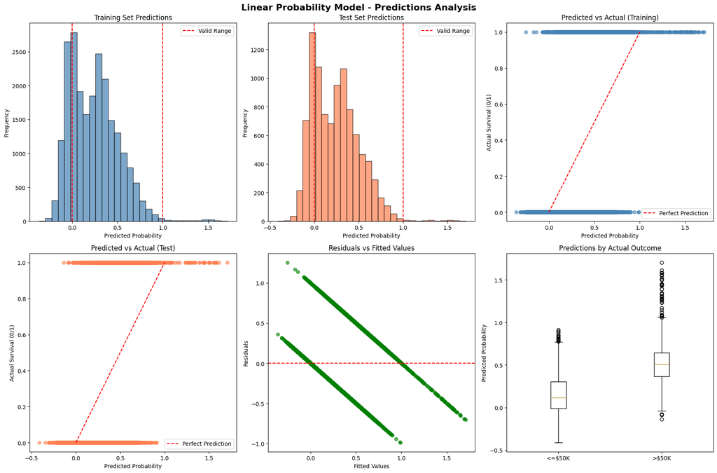

```
MOST EXTREME PREDICTIONS:
Lowest prediction: -0.4127
Highest prediction: 1.7062
```

```python
# Generate predictions for both training and test sets
y_pred_lpm_train = lpm_results.predict(X_train_const)
y_pred_lpm_test = lpm_results.predict(X_test_const)

print("PREDICTION ANALYSIS - LINEAR PROBABILITY MODEL:")
print("-" * 50)

# Check for impossible predictions (outside [0,1])
train_impossible = ((y_pred_lpm_train < 0) | (y_pred_lpm_train > 1)).sum()
test_impossible = ((y_pred_lpm_test < 0) | (y_pred_lpm_test > 1)).sum()

print(f"IMPOSSIBLE PREDICTIONS ANALYSIS:")
print(f"Training set: {train_impossible}/{len(y_pred_lpm_train)} ({train_impossible/len(y_pred_lpm_train)*100:.1f}%) outside [0,1]")
print(f"Test set: {test_impossible}/{len(y_pred_lpm_test)} ({test_impossible/len(y_pred_lpm_test)*100:.1f}%) outside [0,1]")

print(f"\nPREDICTION STATISTICS:")
print("-" * 25)
print(f"Training predictions - Min: {y_pred_lpm_train.min():.4f}, Max: {y_pred_lpm_train.max():.4f}")
print(f"Test predictions - Min: {y_pred_lpm_test.min():.4f}, Max: {y_pred_lpm_test.max():.4f}")

# Create visualization
fig, axes = plt.subplots(2, 3, figsize=(18, 12))
fig.suptitle('Linear Probability Model - Predictions Analysis', fontsize=16, fontweight='bold')

# 1. Histogram of training predictions
ax1 = axes[0, 0]
ax1.hist(y_pred_lpm_train, bins=30, alpha=0.7, color='steelblue', edgecolor='black')
ax1.axvline(0, color='red', linestyle='--', label='Valid Range')
ax1.axvline(1, color='red', linestyle='--')
ax1.set_title('Training Set Predictions')
ax1.set_xlabel('Predicted Probability')
ax1.set_ylabel('Frequency')
ax1.legend()

# 2. Histogram of test predictions
ax2 = axes[0, 1]
ax2.hist(y_pred_lpm_test, bins=30, alpha=0.7, color='coral', edgecolor='black')
ax2.axvline(0, color='red', linestyle='--', label='Valid Range')
ax2.axvline(1, color='red', linestyle='--')
ax2.set_title('Test Set Predictions')
ax2.set_xlabel('Predicted Probability')
ax2.set_ylabel('Frequency')
ax2.legend()

# 3. Predicted vs Actual - Training
ax3 = axes[0, 2]
ax3.scatter(y_pred_lpm_train, y_train, alpha=0.6, color='steelblue')
ax3.plot([0, 1], [0, 1], 'r--', label='Perfect Prediction')
ax3.set_title('Predicted vs Actual (Training)')
ax3.set_xlabel('Predicted Probability')
ax3.set_ylabel('Actual Survival (0/1)')
ax3.legend()

# 4. Predicted vs Actual - Test
ax4 = axes[1, 0]
ax4.scatter(y_pred_lpm_test, y_test, alpha=0.6, color='coral')
ax4.plot([0, 1], [0, 1], 'r--', label='Perfect Prediction')
ax4.set_title('Predicted vs Actual (Test)')
ax4.set_xlabel('Predicted Probability')
ax4.set_ylabel('Actual Survival (0/1)')
ax4.legend()

# 5. Residuals vs Fitted
ax5 = axes[1, 1]
residuals_train = y_train - y_pred_lpm_train
ax5.scatter(y_pred_lpm_train, residuals_train, alpha=0.6, color='green')
ax5.axhline(0, color='red', linestyle='--')
ax5.set_title('Residuals vs Fitted Values')
ax5.set_xlabel('Fitted Values')
ax5.set_ylabel('Residuals')

# 6. Box plot by actual survival
ax6 = axes[1, 2]
survival_groups = [y_pred_lpm_test[y_test == 0], y_pred_lpm_test[y_test == 1]]
ax6.boxplot(survival_groups, labels=['<=$50K', '>$50K'])
ax6.set_title('Predictions by Actual Outcome')
ax6.set_ylabel('Predicted Probability')

plt.tight_layout()
plt.show()

# Identify most problematic predictions
if train_impossible > 0 or test_impossible > 0:
    print(f"\nMOST EXTREME PREDICTIONS:")
    all_predictions = np.concatenate([y_pred_lpm_train, y_pred_lpm_test])
    print(f"Lowest prediction: {all_predictions.min():.4f}")
    print(f"Highest prediction: {all_predictions.max():.4f}")
```

[output not shown]

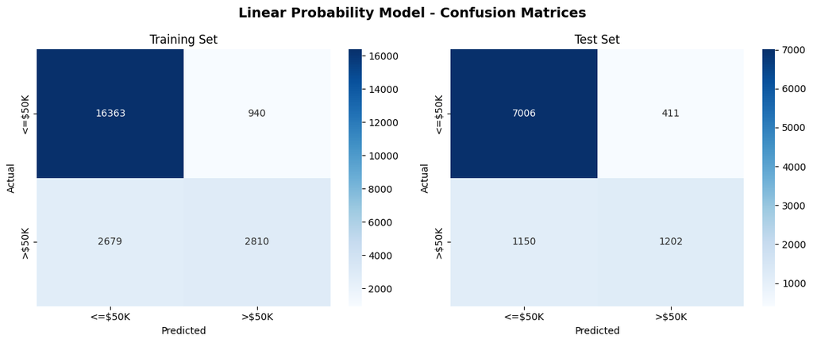

```python
print("LINEAR PROBABILITY MODEL - CLASSIFICATION PERFORMANCE:")
print("-" * 55)

# Convert probabilities to binary predictions using 0.5 threshold
threshold = 0.5
y_pred_binary_train = (y_pred_lpm_train >= threshold).astype(int)
y_pred_binary_test = (y_pred_lpm_test >= threshold).astype(int)

print(f"Using threshold: {threshold}")

# Confusion Matrix Analysis
print("\n" + "="*40)
print("CONFUSION MATRIX ANALYSIS")
print("="*40)

# Training set confusion matrix
cm_train = confusion_matrix(y_train, y_pred_binary_train)
tn_train, fp_train, fn_train, tp_train = cm_train.ravel()

print(f"TRAINING SET CONFUSION MATRIX:")
print("-" * 35)
print("                 Predicted")
print("              <=$50K    <=$50K")
print(f"Actual <=$50K   {tn_train:4d}     {fp_train:4d}")
print(f"       <=$50K  {fn_train:4d}     {tp_train:4d}")

# Test set confusion matrix
cm_test = confusion_matrix(y_test, y_pred_binary_test)
tn_test, fp_test, fn_test, tp_test = cm_test.ravel()

print(f"\nTEST SET CONFUSION MATRIX:")
print("-" * 30)
print("                 Predicted")
print("              <=$50K    <=$50K")
print(f"Actual <=$50K   {tn_test:4d}     {fp_test:4d}")
print(f"       <=$50K  {fn_test:4d}     {tp_test:4d}")

# Calculate all metrics
def calculate_metrics(y_true, y_pred):
    accuracy = accuracy_score(y_true, y_pred)
    precision = precision_score(y_true, y_pred)
    recall = recall_score(y_true, y_pred)
    f1 = f1_score(y_true, y_pred)

    # Calculate specificity manually
    cm = confusion_matrix(y_true, y_pred)
    tn, fp, fn, tp = cm.ravel()
    specificity = tn / (tn + fp) if (tn + fp) > 0 else 0

    return {
        'accuracy': accuracy,
        'precision': precision,
        'recall': recall,
        'specificity': specificity,
        'f1': f1
    }

train_metrics = calculate_metrics(y_train, y_pred_binary_train)
test_metrics = calculate_metrics(y_test, y_pred_binary_test)

# Create metrics comparison table
print("\n" + "="*40)
print("KEY PERFORMANCE METRICS")
print("="*40)

metrics_df = pd.DataFrame({
    'Metric': ['Accuracy', 'Precision', 'Recall', 'Specificity', 'F1-Score'],
    'Formula': [
        '(TP + TN) / Total',
        'TP / (TP + FP)',
        'TP / (TP + FN)',
        'TN / (TN + FP)',
        '2 × (Prec × Recall) / (Prec + Recall)'
    ],
    'Training': [
        train_metrics['accuracy'],
        train_metrics['precision'],
        train_metrics['recall'],
        train_metrics['specificity'],
        train_metrics['f1']
    ],
    'Test': [
        test_metrics['accuracy'],
        test_metrics['precision'],
        test_metrics['recall'],
        test_metrics['specificity'],
        test_metrics['f1']
    ],
    'Interpretation': [
        'Overall correct predictions',
        'Reliability of survival predictions',
        'Ability to catch actual survivors',
        'Ability to identify deaths',
        'Balance of precision and recall'
    ]
})

print(metrics_df.round(4))

print(f"\nDETAILED INTERPRETATION:")
print("-" * 25)
print(f"1. ACCURACY ({test_metrics['accuracy']:.3f}):")
print(f"   → {test_metrics['accuracy']:.1%} of all predictions are correct")

print(f"\n2. PRECISION ({test_metrics['precision']:.3f}):")
print(f"   → Of passengers predicted to survive, {test_metrics['precision']:.1%} actually did")

print(f"\n3. RECALL ({test_metrics['recall']:.3f}):")
print(f"   → Of passengers who actually survived, we identified {test_metrics['recall']:.1%}")

print(f"\n4. SPECIFICITY ({test_metrics['specificity']:.3f}):")
print(f"   → Of passengers who actually died, we correctly identified {test_metrics['specificity']:.1%}")

print(f"\n5. F1-SCORE ({test_metrics['f1']:.3f}):")
print(f"   → Balanced measure combining precision and recall")

# Visualization of confusion matrices
fig, axes = plt.subplots(1, 2, figsize=(12, 5))
fig.suptitle('Linear Probability Model - Confusion Matrices', fontsize=14, fontweight='bold')

# Training confusion matrix
sns.heatmap(cm_train, annot=True, fmt='d', cmap='Blues', ax=axes[0],
            xticklabels=['<=$50K', '>$50K'], yticklabels=['<=$50K', '>$50K'])
axes[0].set_title('Training Set')
axes[0].set_xlabel('Predicted')
axes[0].set_ylabel('Actual')

# Test confusion matrix
sns.heatmap(cm_test, annot=True, fmt='d', cmap='Blues', ax=axes[1],
            xticklabels=['<=$50K', '>$50K'], yticklabels=['<=$50K', '>$50K'])
axes[1].set_title('Test Set')
axes[1].set_xlabel('Predicted')
axes[1].set_ylabel('Actual')

plt.tight_layout()
plt.show()
```

```
DEMONSTRATING LPM PROBLEMS WITH VISUALIZATIONS:
--------------------------------------------------
```

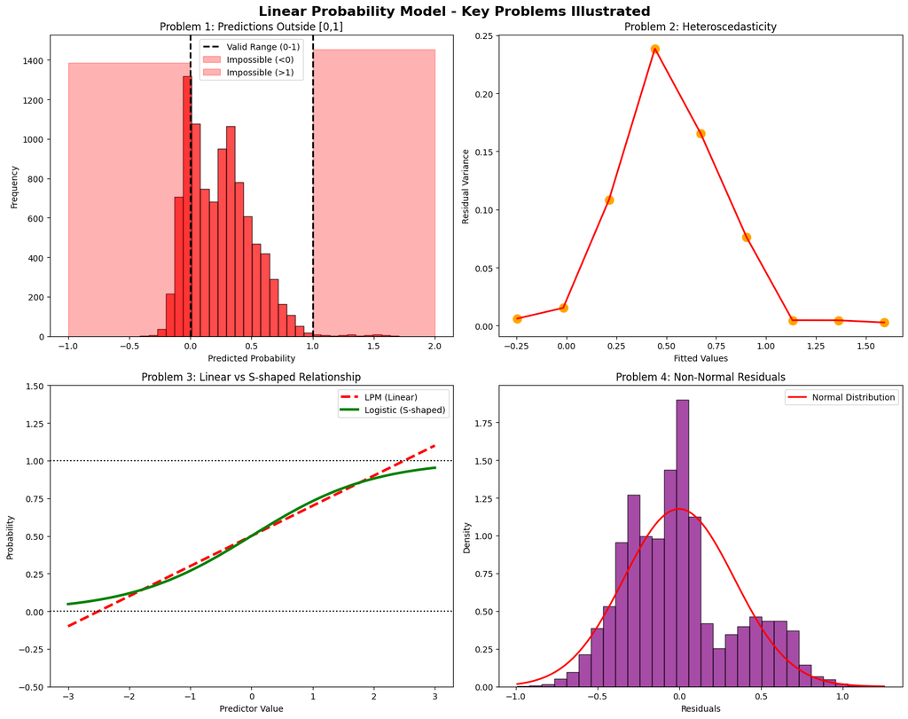

```
PROBLEM QUANTIFICATION:
-------------------------
1. Impossible predictions: 7197 total
2. Heteroscedasticity: Residual variance ranges from 0.0027 to 0.2384
3. Linearity assumption: R² = 0.3713 (low fit suggests non-linearity)
4. Normality: Shapiro-Wilk test p-value = 0.000000

FORMAL DIAGNOSTIC TESTS:
-------------------------
Breusch-Pagan test for heteroscedasticity:
  LM statistic: 5888.3472, p-value: 0.000000
  REJECT null hypothesis of homoscedasticity
```

```python
print("DEMONSTRATING LPM PROBLEMS WITH VISUALIZATIONS:")
print("-" * 50)

# Create comprehensive visualization of LPM problems
fig, axes = plt.subplots(2, 2, figsize=(15, 12))
fig.suptitle('Linear Probability Model - Key Problems Illustrated', fontsize=16, fontweight='bold')

# Problem 1: Impossible Predictions
ax1 = axes[0, 0]
ax1.hist(y_pred_lpm_test, bins=30, alpha=0.7, color='red', edgecolor='black')
ax1.axvline(0, color='black', linestyle='--', linewidth=2, label='Valid Range (0-1)')
ax1.axvline(1, color='black', linestyle='--', linewidth=2)
ax1.fill_betweenx([0, ax1.get_ylim()[1]], -1, 0, alpha=0.3, color='red', label='Impossible (<0)')
ax1.fill_betweenx([0, ax1.get_ylim()[1]], 1, 2, alpha=0.3, color='red', label='Impossible (>1)')
ax1.set_title('Problem 1: Predictions Outside [0,1]')
ax1.set_xlabel('Predicted Probability')
ax1.set_ylabel('Frequency')
ax1.legend()

# Problem 2: Heteroscedasticity (Variance vs Fitted)
ax2 = axes[0, 1]
# Calculate residual variance in bins
bins = np.linspace(y_pred_lpm_train.min(), y_pred_lpm_train.max(), 10)
bin_centers = []
bin_vars = []
for i in range(len(bins)-1):
    mask = (y_pred_lpm_train >= bins[i]) & (y_pred_lpm_train < bins[i+1])
    if np.sum(mask) > 5:  # Only include bins with sufficient data
        residuals_bin = (y_train[mask] - y_pred_lpm_train[mask])
        bin_centers.append((bins[i] + bins[i+1]) / 2)
        bin_vars.append(np.var(residuals_bin))

ax2.scatter(bin_centers, bin_vars, s=100, color='orange')
ax2.plot(bin_centers, bin_vars, color='red', linewidth=2)
ax2.set_title('Problem 2: Heteroscedasticity')
ax2.set_xlabel('Fitted Values')
ax2.set_ylabel('Residual Variance')

# Problem 3: Linear vs S-shaped relationship
ax3 = axes[1, 0]
# Create theoretical comparison
x_theoretical = np.linspace(-3, 3, 100)
linear_prob = 0.5 + 0.2 * x_theoretical  # Linear relationship
logistic_prob = 1 / (1 + np.exp(-x_theoretical))  # S-shaped relationship

ax3.plot(x_theoretical, linear_prob, 'r--', linewidth=3, label='LPM (Linear)')
ax3.plot(x_theoretical, logistic_prob, 'g-', linewidth=3, label='Logistic (S-shaped)')
ax3.axhline(0, color='black', linestyle=':')
ax3.axhline(1, color='black', linestyle=':')
ax3.set_title('Problem 3: Linear vs S-shaped Relationship')
ax3.set_xlabel('Predictor Value')
ax3.set_ylabel('Probability')
ax3.legend()
ax3.set_ylim(-0.5, 1.5)

# Problem 4: Residual distribution (non-normal)
ax4 = axes[1, 1]
residuals = y_train - y_pred_lpm_train
ax4.hist(residuals, bins=30, alpha=0.7, color='purple', edgecolor='black', density=True)
# Overlay normal distribution for comparison
mu, sigma = residuals.mean(), residuals.std()
x_norm = np.linspace(residuals.min(), residuals.max(), 100)
normal_dist = stats.norm.pdf(x_norm, mu, sigma)
ax4.plot(x_norm, normal_dist, 'r-', linewidth=2, label='Normal Distribution')
ax4.set_title('Problem 4: Non-Normal Residuals')
ax4.set_xlabel('Residuals')
ax4.set_ylabel('Density')
ax4.legend()

plt.tight_layout()
plt.show()

# Quantify the problems
print(f"\nPROBLEM QUANTIFICATION:")
print("-" * 25)
print(f"1. Impossible predictions: {test_impossible + train_impossible} total")
print(f"2. Heteroscedasticity: Residual variance ranges from {np.min(bin_vars):.4f} to {np.max(bin_vars):.4f}")
print(f"3. Linearity assumption: R² = {lpm_results.rsquared:.4f} (low fit suggests non-linearity)")
print(f"4. Normality: Shapiro-Wilk test p-value = {stats.shapiro(residuals[:5000] if len(residuals) > 5000 else residuals)[1]:.6f}")

# Additional diagnostic tests
from statsmodels.stats.diagnostic import het_breuschpagan

print(f"\nFORMAL DIAGNOSTIC TESTS:")
print("-" * 25)
# Breusch-Pagan test for heteroscedasticity
bp_lm, bp_lm_pvalue, bp_fvalue, bp_f_pvalue = het_breuschpagan(residuals, X_train_const)
print(f"Breusch-Pagan test for heteroscedasticity:")
print(f"  LM statistic: {bp_lm:.4f}, p-value: {bp_lm_pvalue:.6f}")
print(f"  {'REJECT' if bp_lm_pvalue < 0.05 else 'FAIL TO REJECT'} null hypothesis of homoscedasticity")
```

```
VISUALIZING THE LOGISTIC FUNCTION AND LOG-ODDS TRANSFORMATION:
------------------------------------------------------------
```

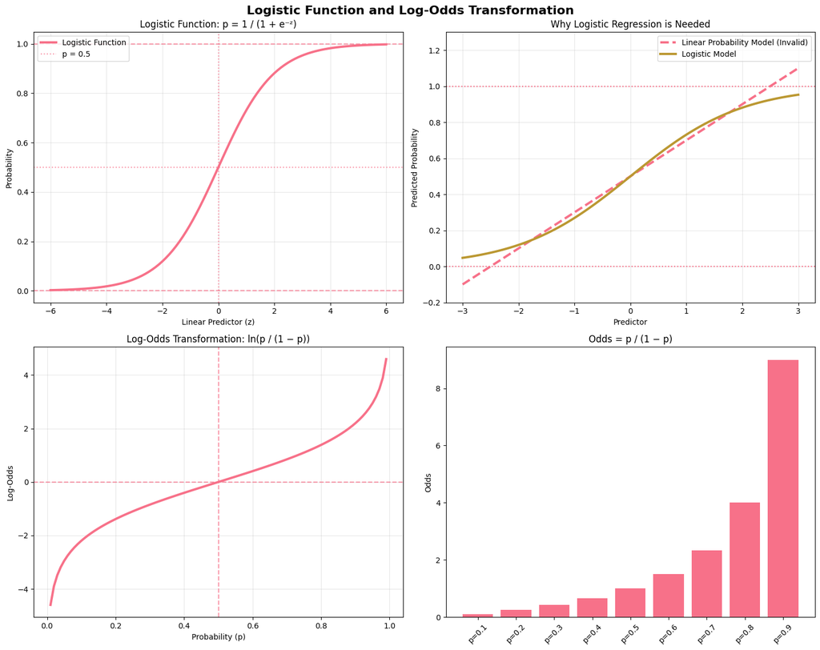

```
PRACTICAL EXAMPLE WITH INCOME DATA:
----------------------------------------
High Income Probability by Age Group:
       count    mean    odds  log_odds
age
0-20    2410  0.0008  0.0008   -7.0922
21-30   8162  0.0833  0.0909   -2.3982
31-40   8546  0.2815  0.3919   -0.9369
41-50   6983  0.3802  0.6134   -0.4887
51-60   4128  0.3748  0.5994   -0.5119
60+     2332  0.2363  0.3094   -1.1732
```

```python
print("VISUALIZING THE LOGISTIC FUNCTION AND LOG-ODDS TRANSFORMATION:")
print("-" * 60)

import numpy as np
import pandas as pd
import matplotlib.pyplot as plt

# Create 2x2 plot layout
fig, axes = plt.subplots(2, 2, figsize=(15, 12))
fig.suptitle('Logistic Function and Log-Odds Transformation', fontsize=16, fontweight='bold')


ax1 = axes[0, 0]
z = np.linspace(-6, 6, 100)
logistic_prob = 1 / (1 + np.exp(-z))

ax1.plot(z, logistic_prob, linewidth=3, label='Logistic Function')
ax1.axhline(0, linestyle='--', alpha=0.7)
ax1.axhline(1, linestyle='--', alpha=0.7)
ax1.axhline(0.5, linestyle=':', alpha=0.7, label='p = 0.5')
ax1.axvline(0, linestyle=':', alpha=0.7)
ax1.set_title('Logistic Function: p = 1 / (1 + e⁻ᶻ)')
ax1.set_xlabel('Linear Predictor (z)')
ax1.set_ylabel('Probability')
ax1.grid(True, alpha=0.3)
ax1.legend()


ax2 = axes[0, 1]
z_comp = np.linspace(-3, 3, 100)
linear_comp = 0.5 + 0.2 * z_comp
logistic_comp = 1 / (1 + np.exp(-z_comp))

ax2.plot(z_comp, linear_comp, '--', linewidth=3, label='Linear Probability Model (Invalid)')
ax2.plot(z_comp, logistic_comp, linewidth=3, label='Logistic Model')
ax2.axhline(0, linestyle=':')
ax2.axhline(1, linestyle=':')
ax2.set_ylim(-0.2, 1.3)
ax2.set_title('Why Logistic Regression is Needed')
ax2.set_xlabel('Predictor')
ax2.set_ylabel('Predicted Probability')
ax2.legend()
ax2.grid(True, alpha=0.3)

ax3 = axes[1, 0]
p_values = np.linspace(0.01, 0.99, 100)
log_odds = np.log(p_values / (1 - p_values))

ax3.plot(p_values, log_odds, linewidth=3)
ax3.axhline(0, linestyle='--', alpha=0.7)
ax3.axvline(0.5, linestyle='--', alpha=0.7)
ax3.set_title('Log-Odds Transformation: ln(p / (1 − p))')
ax3.set_xlabel('Probability (p)')
ax3.set_ylabel('Log-Odds')
ax3.grid(True, alpha=0.3)

ax4 = axes[1, 1]
p_demo = np.array([0.1, 0.2, 0.3, 0.4, 0.5, 0.6, 0.7, 0.8, 0.9])
odds_demo = p_demo / (1 - p_demo)

ax4.bar(range(len(p_demo)), odds_demo)
ax4.set_xticks(range(len(p_demo)))
ax4.set_xticklabels([f'p={p:.1f}' for p in p_demo], rotation=45)
ax4.set_title('Odds = p / (1 − p)')
ax4.set_ylabel('Odds')

plt.tight_layout()
plt.show()

print("\nPRACTICAL EXAMPLE WITH INCOME DATA:")
print("-" * 40)

# Create age bins
age_bins = pd.cut(
    dfdum['age'],
    bins=[0, 20, 30, 40, 50, 60, 100],
    labels=['0-20', '21-30', '31-40', '41-50', '51-60', '60+']
)

# Group by age and compute probability of high income
age_stats = (
    dfdum
    .groupby(age_bins)['high_income']
    .agg(['count', 'mean'])
    .dropna()
)

# Safe log-odds computation (avoid log(0))
eps = 1e-6
age_stats['odds'] = (age_stats['mean'] + eps) / (1 - age_stats['mean'] + eps)
age_stats['log_odds'] = np.log(age_stats['odds'])

print("High Income Probability by Age Group:")
print(age_stats.round(4))
```

```python
print("FITTING LOGISTIC REGRESSION USING MAXIMUM LIKELIHOOD ESTIMATION:")
print("-" * 65)

print("Model specification:")
print("where p = P(survived = 1)")

# Fit logistic regression model using statsmodels
logit_model = sm.Logit(y_train, X_train_const)
logit_results = logit_model.fit()

print(f"\nMODEL FITTING COMPLETE:")
print(f"- Estimation method: Maximum Likelihood Estimation (MLE)")
print(f"- Number of observations: {logit_results.nobs}")
print(f"- Number of parameters: {len(logit_results.params)}")
print(f"- Degrees of freedom: {logit_results.df_resid}")
print(f"- Convergence achieved: {'Yes' if logit_results.mle_retvals['converged'] else 'No'}")
print(f"- Number of iterations: {logit_results.mle_retvals.get('iterations', 'N/A')}")
```

```
FITTING LOGISTIC REGRESSION USING MAXIMUM LIKELIHOOD ESTIMATION:
-----------------------------------------------------------------
Model specification:
where p = P(survived = 1)
Warning: Maximum number of iterations has been exceeded.
         Current function value: 0.313979
         Iterations: 35

MODEL FITTING COMPLETE:
- Estimation method: Maximum Likelihood Estimation (MLE)
- Number of observations: 22792
- Number of parameters: 71
- Degrees of freedom: 22729.0
- Convergence achieved: No
- Number of iterations: 35
```

```python
print("LOGISTIC REGRESSION RESULTS:")
print("-" * 35)
print(logit_results.summary())
```

```
LOGISTIC REGRESSION RESULTS:
-----------------------------------
                           Logit Regression Results
==============================================================================
Dep. Variable:            high_income   No. Observations:                22792
Model:                          Logit   Df Residuals:                    22729
Method:                           MLE   Df Model:                           62
Date:                Sat, 31 Jan 2026   Pseudo R-squ.:                  0.4312
Time:                        17:21:16   Log-Likelihood:                -7156.2
converged:                      False   LL-Null:                       -12582.
Covariance Type:            nonrobust   LLR p-value:                     0.000
========================================================================================================
                                           coef    std err          z      P>|z|      [0.025      0.975]
--------------------------------------------------------------------------------------------------------
const                                   -6.7303   6.82e+05  -9.87e-06      1.000   -1.34e+06    1.34e+06
age                                      0.0250      0.002     12.654      0.000       0.021       0.029
fnlwgt                                7.161e-07   2.04e-07      3.512      0.000    3.16e-07    1.12e-06
education.num                            0.8038    7.3e+04    1.1e-05      1.000   -1.43e+05    1.43e+05
capital.gain                             0.0003   1.21e-05     26.021      0.000       0.000       0.000
capital.loss                             0.0006   4.45e-05     14.259      0.000       0.001       0.001
hours.per.week                           0.0300      0.002     15.362      0.000       0.026       0.034
work_Federal-gov                        -0.0056   3.92e+05  -1.42e-08      1.000   -7.68e+05    7.68e+05
work_Local-gov                          -0.8069      4e+05  -2.02e-06      1.000   -7.85e+05    7.85e+05
work_Never-worked                      -20.2062   5.66e+04     -0.000      1.000   -1.11e+05    1.11e+05
work_Private                            -0.6327   3.98e+05  -1.59e-06      1.000   -7.81e+05    7.81e+05
work_Self-emp-inc                       -0.5619      4e+05   -1.4e-06      1.000   -7.84e+05    7.84e+05
work_Self-emp-not-inc                   -1.1022   3.94e+05   -2.8e-06      1.000   -7.72e+05    7.72e+05
work_State-gov                          -1.0213   4.03e+05  -2.53e-06      1.000    -7.9e+05     7.9e+05
work_Without-pay                       -10.3125   4.04e+05  -2.55e-05      1.000   -7.91e+05    7.91e+05
education_10th                           2.6679        nan        nan        nan         nan         nan
education_11th                           2.1203        nan        nan        nan         nan         nan
education_12th                           2.0024        nan        nan        nan         nan         nan
education_1st-4th                        5.7372        nan        nan        nan         nan         nan
education_5th-6th                        4.9677        nan        nan        nan         nan         nan
education_7th-8th                        3.7441        nan        nan        nan         nan         nan
education_9th                            3.4900        nan        nan        nan         nan         nan
education_Assoc-acdm                    -0.7194   5.45e+05  -1.32e-06      1.000   -1.07e+06    1.07e+06
education_Assoc-voc                      0.1707   4.45e+05   3.84e-07      1.000   -8.72e+05    8.72e+05
education_Bachelors                     -0.8783   5.63e+05  -1.56e-06      1.000    -1.1e+06     1.1e+06
education_Doctorate                     -2.1297   9.05e+05  -2.35e-06      1.000   -1.77e+06    1.77e+06
```

[output cut: 31 more lines]

```
relationship_Wife                        0.1724        nan        nan        nan         nan         nan
race_Amer-Indian-Eskimo                 -1.6451        nan        nan        nan         nan         nan
race_Asian-Pac-Islander                 -1.2509        nan        nan        nan         nan         nan
race_Black                              -1.3126        nan        nan        nan         nan         nan
race_Other                              -1.3752        nan        nan        nan         nan         nan
race_White                              -1.1465        nan        nan        nan         nan         nan
sex_Female                              -3.7621        nan        nan        nan         nan         nan
sex_Male                                -2.9682        nan        nan        nan         nan         nan
country_Canada                          -1.0609   8.22e+05  -1.29e-06      1.000   -1.61e+06    1.61e+06
country_Germany                         -0.6912   8.22e+05  -8.41e-07      1.000   -1.61e+06    1.61e+06
country_Mexico                          -1.7844   8.22e+05  -2.17e-06      1.000   -1.61e+06    1.61e+06
country_Other_countries                 -1.5147   8.22e+05  -1.84e-06      1.000   -1.61e+06    1.61e+06
country_Philippines                     -0.5690   8.22e+05  -6.92e-07      1.000   -1.61e+06    1.61e+06
country_United-States                   -1.1101   8.22e+05  -1.35e-06      1.000   -1.61e+06    1.61e+06
========================================================================================================
```

```
PREDICTION ANALYSIS - LOGISTIC REGRESSION:
---------------------------------------------
PREDICTION RANGE VERIFICATION:
Training predictions - Min: 0.000000, Max: 1.000000
Test predictions - Min: 0.000000, Max: 1.000000
All predictions in [0,1]: ✓ YES
```

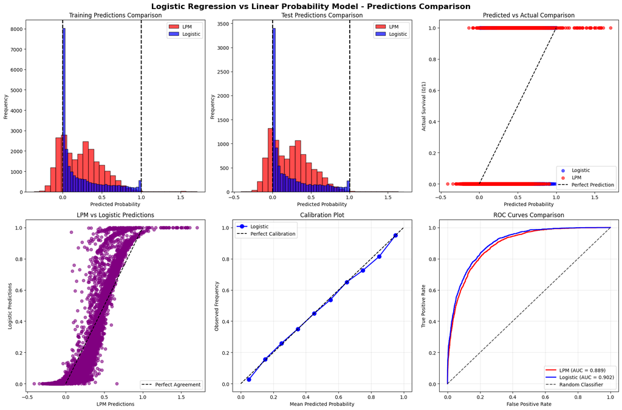

```
PREDICTION COMPARISON STATISTICS:
-----------------------------------
Correlation between LPM and Logistic predictions: 0.9065
Mean absolute difference: 0.0899
Maximum absolute difference: 0.8987
```

```python
# Generate predictions from logistic model
y_pred_logit_train = logit_results.predict(X_train_const)
y_pred_logit_test = logit_results.predict(X_test_const)

print("PREDICTION ANALYSIS - LOGISTIC REGRESSION:")
print("-" * 45)

# Verify all predictions are in valid range
print(f"PREDICTION RANGE VERIFICATION:")
print(f"Training predictions - Min: {y_pred_logit_train.min():.6f}, Max: {y_pred_logit_train.max():.6f}")
print(f"Test predictions - Min: {y_pred_logit_test.min():.6f}, Max: {y_pred_logit_test.max():.6f}")
print(f"All predictions in [0,1]: {'✓ YES' if (y_pred_logit_train.min() >= 0 and y_pred_logit_train.max() <= 1 and y_pred_logit_test.min() >= 0 and y_pred_logit_test.max() <= 1) else '✗ NO'}")

# Create comparison visualization
fig, axes = plt.subplots(2, 3, figsize=(18, 12))
fig.suptitle('Logistic Regression vs Linear Probability Model - Predictions Comparison',
             fontsize=16, fontweight='bold')

# 1. Histogram comparison - Training
ax1 = axes[0, 0]
ax1.hist(y_pred_lpm_train, bins=30, alpha=0.7, label='LPM', color='red', edgecolor='black')
ax1.hist(y_pred_logit_train, bins=30, alpha=0.7, label='Logistic', color='blue', edgecolor='black')
ax1.axvline(0, color='black', linestyle='--', linewidth=2)
ax1.axvline(1, color='black', linestyle='--', linewidth=2)
ax1.set_title('Training Predictions Comparison')
ax1.set_xlabel('Predicted Probability')
ax1.set_ylabel('Frequency')
ax1.legend()

# 2. Histogram comparison - Test
ax2 = axes[0, 1]
ax2.hist(y_pred_lpm_test, bins=30, alpha=0.7, label='LPM', color='red', edgecolor='black')
ax2.hist(y_pred_logit_test, bins=30, alpha=0.7, label='Logistic', color='blue', edgecolor='black')
ax2.axvline(0, color='black', linestyle='--', linewidth=2)
ax2.axvline(1, color='black', linestyle='--', linewidth=2)
ax2.set_title('Test Predictions Comparison')
ax2.set_xlabel('Predicted Probability')
ax2.set_ylabel('Frequency')
ax2.legend()

# 3. Predicted vs Actual - Logistic
ax3 = axes[0, 2]
ax3.scatter(y_pred_logit_test, y_test, alpha=0.6, color='blue', label='Logistic')
ax3.scatter(y_pred_lpm_test, y_test, alpha=0.6, color='red', label='LPM')
ax3.plot([0, 1], [0, 1], 'k--', label='Perfect Prediction')
ax3.set_title('Predicted vs Actual Comparison')
ax3.set_xlabel('Predicted Probability')
ax3.set_ylabel('Actual Survival (0/1)')
ax3.legend()

# 4. Direct comparison of predictions
ax4 = axes[1, 0]
ax4.scatter(y_pred_lpm_test, y_pred_logit_test, alpha=0.6, color='purple')
ax4.plot([0, 1], [0, 1], 'k--', label='Perfect Agreement')
ax4.set_title('LPM vs Logistic Predictions')
ax4.set_xlabel('LPM Predictions')
ax4.set_ylabel('Logistic Predictions')
ax4.legend()

# 5. Calibration plot
ax5 = axes[1, 1]
# Create bins and calculate observed frequencies
n_bins = 10
bin_boundaries = np.linspace(0, 1, n_bins + 1)

# For logistic regression
logit_bin_centers = []
logit_observed = []
for i in range(n_bins):
    mask = (y_pred_logit_test >= bin_boundaries[i]) & (y_pred_logit_test < bin_boundaries[i+1])
    if mask.sum() > 0:
        logit_bin_centers.append((bin_boundaries[i] + bin_boundaries[i+1]) / 2)
        logit_observed.append(y_test[mask].mean())

ax5.plot(logit_bin_centers, logit_observed, 'bo-', label='Logistic', linewidth=2, markersize=8)
ax5.plot([0, 1], [0, 1], 'k--', label='Perfect Calibration')
ax5.set_title('Calibration Plot')
ax5.set_xlabel('Mean Predicted Probability')
ax5.set_ylabel('Observed Frequency')
ax5.legend()
ax5.grid(True, alpha=0.3)

# 6. ROC Curves comparison
ax6 = axes[1, 2]
# Calculate ROC for both models
fpr_lpm, tpr_lpm, _ = roc_curve(y_test, y_pred_lpm_test)  # Fixed: was fpr_lmp, should be fpr_lpm
fpr_logit, tpr_logit, _ = roc_curve(y_test, y_pred_logit_test)
auc_lpm = roc_auc_score(y_test, y_pred_lpm_test)
auc_logit = roc_auc_score(y_test, y_pred_logit_test)

ax6.plot(fpr_lpm, tpr_lpm, 'r-', linewidth=2, label=f'LPM (AUC = {auc_lpm:.3f})')  # Now works correctly
ax6.plot(fpr_logit, tpr_logit, 'b-', linewidth=2, label=f'Logistic (AUC = {auc_logit:.3f})')
ax6.plot([0, 1], [0, 1], 'k--', alpha=0.7, label='Random Classifier')
ax6.set_title('ROC Curves Comparison')
ax6.set_xlabel('False Positive Rate')
ax6.set_ylabel('True Positive Rate')
ax6.legend()
ax6.grid(True, alpha=0.3)

plt.tight_layout()
plt.show()

# Print comparison statistics
print(f"\nPREDICTION COMPARISON STATISTICS:")
print("-" * 35)
print(f"Correlation between LPM and Logistic predictions: {np.corrcoef(y_pred_lpm_test, y_pred_logit_test)[0,1]:.4f}")
print(f"Mean absolute difference: {np.mean(np.abs(y_pred_lpm_test - y_pred_logit_test)):.4f}")
print(f"Maximum absolute difference: {np.max(np.abs(y_pred_lpm_test - y_pred_logit_test)):.4f}")
```

# Accuracy Classification and Performance Analysis

Here we analyze the accuracy of my model, whether the R square is acceptable or not

```
LOGISTIC REGRESSION - CLASSIFICATION PERFORMANCE:
--------------------------------------------------
CONFUSION MATRICES:
--------------------
```

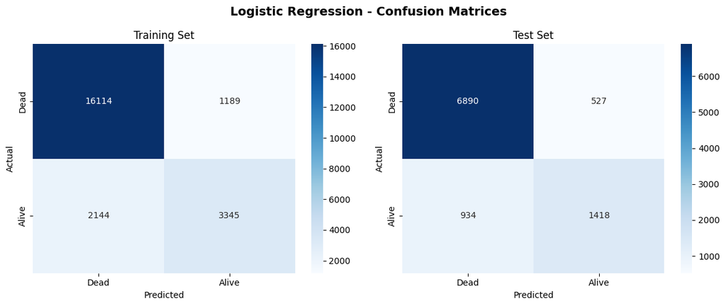

```
CLASSIFICATION METRICS COMPARISON:
----------------------------------------
        Metric  LPM_Train  LPM_Test  Logistic_Train  Logistic_Test
0     Accuracy     0.8412    0.8402          0.8538         0.8504
1    Precision     0.7493    0.7452          0.7378         0.7290
2       Recall     0.5119    0.5111          0.6094         0.6029
3  Specificity     0.9457    0.9446          0.9313         0.9289
4     F1-Score     0.6083    0.6063          0.6675         0.6600

ROC ANALYSIS:
---------------
LPM AUC: 0.8888
Logistic AUC: 0.9021
AUC Improvement: 0.0132
```

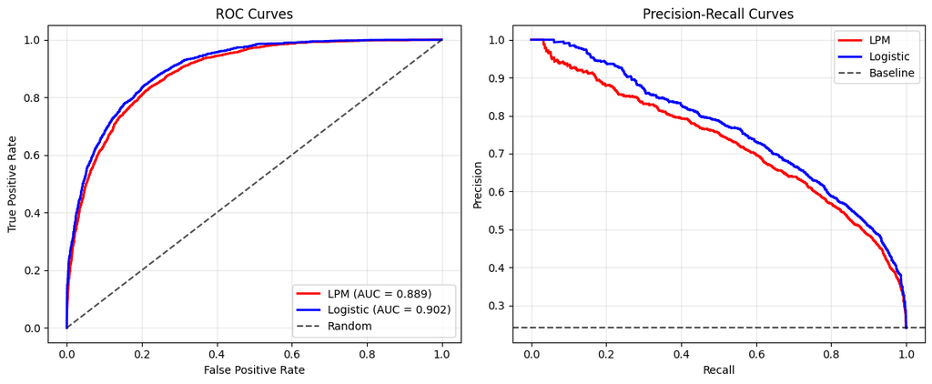

```python
print("LOGISTIC REGRESSION - CLASSIFICATION PERFORMANCE:")
print("-" * 50)

# Convert probabilities to binary predictions
y_pred_logit_binary_train = (y_pred_logit_train >= 0.5).astype(int)
y_pred_logit_binary_test = (y_pred_logit_test >= 0.5).astype(int)

# Calculate confusion matrices
cm_logit_train = confusion_matrix(y_train, y_pred_logit_binary_train)
cm_logit_test = confusion_matrix(y_test, y_pred_logit_binary_test)

print("CONFUSION MATRICES:")
print("-" * 20)

# Display confusion matrices
fig, axes = plt.subplots(1, 2, figsize=(12, 5))
fig.suptitle('Logistic Regression - Confusion Matrices', fontsize=14, fontweight='bold')

sns.heatmap(cm_logit_train, annot=True, fmt='d', cmap='Blues', ax=axes[0],
            xticklabels=['Dead', 'Alive'], yticklabels=['Dead', 'Alive'])
axes[0].set_title('Training Set')
axes[0].set_xlabel('Predicted')
axes[0].set_ylabel('Actual')

sns.heatmap(cm_logit_test, annot=True, fmt='d', cmap='Blues', ax=axes[1],
            xticklabels=['Dead', 'Alive'], yticklabels=['Dead', 'Alive'])
axes[1].set_title('Test Set')
axes[1].set_xlabel('Predicted')
axes[1].set_ylabel('Actual')

plt.tight_layout()
plt.show()

# Calculate comprehensive metrics
logit_train_metrics = calculate_metrics(y_train, y_pred_logit_binary_train)
logit_test_metrics = calculate_metrics(y_test, y_pred_logit_binary_test)

print("\nCLASSIFICATION METRICS COMPARISON:")
print("-" * 40)

# Create comprehensive comparison
comparison_df = pd.DataFrame({
    'Metric': ['Accuracy', 'Precision', 'Recall', 'Specificity', 'F1-Score'],
    'LPM_Train': [train_metrics['accuracy'], train_metrics['precision'],
                 train_metrics['recall'], train_metrics['specificity'], train_metrics['f1']],
    'LPM_Test': [test_metrics['accuracy'], test_metrics['precision'],
                test_metrics['recall'], test_metrics['specificity'], test_metrics['f1']],
    'Logistic_Train': [logit_train_metrics['accuracy'], logit_train_metrics['precision'],
                      logit_train_metrics['recall'], logit_train_metrics['specificity'],
                      logit_train_metrics['f1']],
    'Logistic_Test': [logit_test_metrics['accuracy'], logit_test_metrics['precision'],
                     logit_test_metrics['recall'], logit_test_metrics['specificity'],
                     logit_test_metrics['f1']]
})

print(comparison_df.round(4))

# ROC Analysis
print(f"\nROC ANALYSIS:")
print("-" * 15)
print(f"LPM AUC: {auc_lpm:.4f}")
print(f"Logistic AUC: {auc_logit:.4f}")
print(f"AUC Improvement: {auc_logit - auc_lpm:.4f}")

# Create comprehensive ROC and PR curves
fig, axes = plt.subplots(1, 2, figsize=(12, 5))

# ROC Curves
fpr_lmp, tpr_lpm, thresholds_lpm = roc_curve(y_test, y_pred_lpm_test)
fpr_logit, tpr_logit, thresholds_logit = roc_curve(y_test, y_pred_logit_test)

axes[0].plot(fpr_lpm, tpr_lpm, 'r-', linewidth=2, label=f'LPM (AUC = {auc_lpm:.3f})')
axes[0].plot(fpr_logit, tpr_logit, 'b-', linewidth=2, label=f'Logistic (AUC = {auc_logit:.3f})')
axes[0].plot([0, 1], [0, 1], 'k--', alpha=0.7, label='Random')
axes[0].set_xlabel('False Positive Rate')
axes[0].set_ylabel('True Positive Rate')
axes[0].set_title('ROC Curves')
axes[0].legend()
axes[0].grid(True, alpha=0.3)

# Precision-Recall Curves
precision_lpm, recall_lpm, _ = precision_recall_curve(y_test, y_pred_lpm_test)
precision_logit, recall_logit, _ = precision_recall_curve(y_test, y_pred_logit_test)

axes[1].plot(recall_lpm, precision_lpm, 'r-', linewidth=2, label='LPM')
axes[1].plot(recall_logit, precision_logit, 'b-', linewidth=2, label='Logistic')
axes[1].axhline(y=y_test.mean(), color='k', linestyle='--', alpha=0.7, label='Baseline')
axes[1].set_xlabel('Recall')
axes[1].set_ylabel('Precision')
axes[1].set_title('Precision-Recall Curves')
axes[1].legend()
axes[1].grid(True, alpha=0.3)

plt.tight_layout()
plt.show()
```

My model has an 84.02% chance to be accurate for our LPM model and 85.04 % chance to be correct for Logistic Regression Test. This is good as the values are not far from the training data.

## SECOND ITERATION TUNED MODELLING TEST

```python
dfdums = dfdum.drop(
    columns=[col for col in dfdum.columns if col.startswith('relationship_')]
)
```

```python
# Separate features and target
X_tuned = dfdums.drop(['high_income', 'income'], axis=1)
y_tuned = dfdums['high_income']

print("PREPARING DATA FOR MODELING:")
print("-" * 30)
print(f"Features selected: {X}")
print(f"Target variable: survived")
print(f"Total observations: {len(X)}")
print(f"Missing values in features: {X.isnull().sum().sum()}")

# Check class balance before split
print(f"\nClass distribution in full dataset:")
class_dist = y.value_counts(normalize=True)
print(class_dist)
print(f"Survival rate: {y.mean():.3f}")

# Perform stratified train-test split
X_tuned_train, X_tuned_test, y_traint, y_test = train_test_split(
    X, y,
    test_size=0.3,
    random_state=42,
    stratify=y  # Ensures same proportion of survivors in train and test
)

#Print the information for readability purposes

print(f"\nTRAIN-TEST SPLIT RESULTS:")
print("-" * 30)
print(f"Training set size: {len(X_tuned_train)} ({len(X_tuned_train)/len(X_tuned)*100:.1f}%)")
print(f"Test set size: {len(X_tuned_test)} ({len(X_tuned_test)/len(X_tuned)*100:.1f}%)")

print(f"\nClass distribution verification:")
print(f"Full dataset survival rate: {y.mean():.4f}")
print(f"Training set survival rate: {y_traint.mean():.4f}")
print(f"Test set survival rate: {y_test.mean():.4f}")

print(f"\nTraining set feature statistics:")
print(X_tuned_train.describe())
```

```
PREPARING DATA FOR MODELING:
------------------------------
Features selected:        age  fnlwgt  education.num  capital.gain  capital.loss  hours.per.week  \
0       90   77053              9             0          4356              40
1       82  132870              9             0          4356              18
2       66  186061             10             0          4356              40
3       54  140359              4             0          3900              40
4       41  264663             10             0          3900              40
...    ...     ...            ...           ...           ...             ...
32556   22  310152             10             0             0              40
32557   27  257302             12             0             0              38
32558   40  154374              9             0             0              40
32559   58  151910              9             0             0              40
32560   22  201490              9             0             0              20

       work_Federal-gov  work_Local-gov  work_Never-worked  work_Private  ...  \
0                     0               0                  0             0  ...
1                     0               0                  0             1  ...
2                     0               0                  0             0  ...
3                     0               0                  0             1  ...
4                     0               0                  0             1  ...
...                 ...             ...                ...           ...  ...
32556                 0               0                  0             1  ...
32557                 0               0                  0             1  ...
32558                 0               0                  0             1  ...
32559                 0               0                  0             1  ...
32560                 0               0                  0             1  ...

       race_Other  race_White  sex_Female  sex_Male  country_Canada  \
0               0           1           1         0               0
1               0           1           1         0               0
2               0           0           1         0               0
3               0           1           1         0               0
4               0           1           1         0               0
...           ...         ...         ...       ...             ...
32556           0           1           0         1               0
32557           0           1           1         0               0
32558           0           1           0         1               0
32559           0           1           1         0               0
32560           0           1           0         1               0
```

[output cut: 86 more lines]

```
50%        1.000000        0.000000         0.000000        0.000000
75%        1.000000        0.000000         0.000000        0.000000
max        1.000000        1.000000         1.000000        1.000000

       country_Other_countries  country_Philippines  country_United-States
count             22792.000000         22792.000000           22792.000000
mean                  0.070946             0.006537               0.895402
std                   0.256740             0.080591               0.306042
min                   0.000000             0.000000               0.000000
25%                   0.000000             0.000000               1.000000
50%                   0.000000             0.000000               1.000000
75%                   0.000000             0.000000               1.000000
max                   1.000000             1.000000               1.000000

[8 rows x 70 columns]
```

```python
# Verify that the split maintains similar distributions
print("\nTarget Variable Distribution Comparison:")
print("                Training    Test     Original")
print(f"Mean:          {y_traint.mean():.3f}     {y_test.mean():.3f}    {y.mean():.3f}")
print(f"Std Dev:       {y_traint.std():.3f}     {y_test.std():.3f}    {y.std():.3f}")
print(f"Min:           {y_traint.min():.3f}     {y_test.min():.3f}    {y.min():.3f}")
print(f"Max:           {y_traint.max():.3f}     {y_test.max():.3f}    {y.max():.3f}")

# Check feature distributions
print("\nFeature distributions are similar between train and test sets:")
for column in X_tuned.columns:
    train_mean = X_tuned_train[column].mean()
    test_mean = X_tuned_test[column].mean()
    diff_pct = abs(train_mean - test_mean) / train_mean * 100
    print(f"{column:12}: Train={train_mean:7.3f}, Test={test_mean:7.3f}, Diff={diff_pct:5.2f}%")
```

```
Target Variable Distribution Comparison:
                Training    Test     Original
Mean:          0.241     0.241    0.241
Std Dev:       0.428     0.428    0.428
Min:           0.000     0.000    0.000
Max:           1.000     1.000    1.000

Feature distributions are similar between train and test sets:
age         : Train= 38.531, Test= 38.700, Diff= 0.44%
fnlwgt      : Train=190134.599, Test=188947.242, Diff= 0.62%
education.num: Train= 10.077, Test= 10.088, Diff= 0.11%
capital.gain: Train=1114.312, Test=992.111, Diff=10.97%
capital.loss: Train= 88.058, Test= 85.545, Diff= 2.85%
hours.per.week: Train= 40.397, Test= 40.532, Diff= 0.33%
work_Federal-gov: Train=  0.029, Test=  0.030, Diff= 2.99%
work_Local-gov: Train=  0.065, Test=  0.063, Diff= 3.59%
work_Never-worked: Train=  0.000, Test=  0.000, Diff=74.98%
work_Private: Train=  0.696, Test=  0.700, Diff= 0.71%
work_Self-emp-inc: Train=  0.035, Test=  0.033, Diff= 4.14%
work_Self-emp-not-inc: Train=  0.078, Test=  0.079, Diff= 1.06%
work_State-gov: Train=  0.040, Test=  0.039, Diff= 3.78%
work_Without-pay: Train=  0.000, Test=  0.000, Diff= 6.68%
education_10th: Train=  0.029, Test=  0.029, Diff= 1.06%
education_11th: Train=  0.037, Test=  0.034, Diff= 9.65%
education_12th: Train=  0.013, Test=  0.014, Diff=11.48%
education_1st-4th: Train=  0.005, Test=  0.005, Diff= 6.68%
education_5th-6th: Train=  0.010, Test=  0.010, Diff= 4.11%
education_7th-8th: Train=  0.020, Test=  0.019, Diff= 6.37%
education_9th: Train=  0.016, Test=  0.016, Diff= 1.12%
education_Assoc-acdm: Train=  0.033, Test=  0.031, Diff= 6.19%
education_Assoc-voc: Train=  0.043, Test=  0.042, Diff= 1.59%
education_Bachelors: Train=  0.164, Test=  0.164, Diff= 0.03%
education_Doctorate: Train=  0.013, Test=  0.013, Diff= 3.60%
education_HS-grad: Train=  0.321, Test=  0.326, Diff= 1.62%
education_Masters: Train=  0.053, Test=  0.052, Diff= 3.27%
education_Preschool: Train=  0.002, Test=  0.001, Diff=11.72%
education_Prof-school: Train=  0.018, Test=  0.018, Diff= 2.66%
education_Some-college: Train=  0.223, Test=  0.226, Diff= 1.15%
marital_status_Divorced: Train=  0.138, Test=  0.133, Diff= 3.71%
marital_status_Married-AF-spouse: Train=  0.001, Test=  0.001, Diff= 2.07%
```

[output cut: 17 more lines]

```
occupation_Tech-support: Train=  0.027, Test=  0.031, Diff=12.56%
occupation_Transport-moving: Train=  0.047, Test=  0.053, Diff=12.97%
race_Amer-Indian-Eskimo: Train=  0.009, Test=  0.010, Diff= 5.75%
race_Asian-Pac-Islander: Train=  0.032, Test=  0.032, Diff= 0.33%
race_Black  : Train=  0.098, Test=  0.091, Diff= 6.76%
race_Other  : Train=  0.009, Test=  0.008, Diff= 7.40%
race_White  : Train=  0.852, Test=  0.859, Diff= 0.80%
sex_Female  : Train=  0.331, Test=  0.329, Diff= 0.69%
sex_Male    : Train=  0.669, Test=  0.671, Diff= 0.34%
country_Canada: Train=  0.004, Test=  0.004, Diff= 6.82%
country_Germany: Train=  0.004, Test=  0.004, Diff=10.45%
country_Mexico: Train=  0.019, Test=  0.021, Diff=10.77%
country_Other_countries: Train=  0.071, Test=  0.069, Diff= 2.61%
country_Philippines: Train=  0.007, Test=  0.005, Diff=23.27%
country_United-States: Train=  0.895, Test=  0.897, Diff= 0.17%
```

```python
#Use lpm as the data is binary, linear regression would think that the r squared is low since the values are always low
#LPM will be the compatible model so we will be using that

print("FITTING LINEAR PROBABILITY MODEL (LPM) USING OLS:")
print("-" * 50)

# Add constant term for intercept (required by statsmodels)
X_train_constt = sm.add_constant(X_tuned_train)
X_test_constt = sm.add_constant(X_tuned_test)

print("Model specification:")
print("survived = β₀ + β₁(pclass) + β₂(male) + β₃(age) + β₄(fare) + β₅(family_size) + ε")
print("\nWhere:")
print("- survived: 1 = survived, 0 = died")
print("- pclass: passenger class (1=First, 2=Second, 3=Third)")
print("- male: 1 = male, 0 = female")
print("- age: age in years")
print("- fare: ticket fare")
print("- family_size: number of family members + self")

# Fit the Linear Probability Model using OLS
lpm_model = sm.OLS(y_traint, X_train_constt)
lpm_results = lpm_model.fit()

print(f"\nMODEL FITTING COMPLETE:")
print(f"- Estimation method: Ordinary Least Squares (OLS)")
print(f"- Number of observations: {lpm_results.nobs}")
print(f"- Number of parameters: {len(lpm_results.params)}")
print(f"- Degrees of freedom: {lpm_results.df_resid}")
```

```
FITTING LINEAR PROBABILITY MODEL (LPM) USING OLS:
--------------------------------------------------
Model specification:
survived = β₀ + β₁(pclass) + β₂(male) + β₃(age) + β₄(fare) + β₅(family_size) + ε

Where:
- survived: 1 = survived, 0 = died
- pclass: passenger class (1=First, 2=Second, 3=Third)
- male: 1 = male, 0 = female
- age: age in years
- fare: ticket fare
- family_size: number of family members + self

MODEL FITTING COMPLETE:
- Estimation method: Ordinary Least Squares (OLS)
- Number of observations: 22792.0
- Number of parameters: 71
- Degrees of freedom: 22729.0
```

```
PREDICTION ANALYSIS - LINEAR PROBABILITY MODEL:
--------------------------------------------------
IMPOSSIBLE PREDICTIONS ANALYSIS:
Training set: 5053/22792 (22.2%) outside [0,1]
Test set: 2144/9769 (21.9%) outside [0,1]

PREDICTION STATISTICS:
-------------------------
Training predictions - Min: -0.3604, Max: 1.7062
Test predictions - Min: -0.4127, Max: 1.7039
```

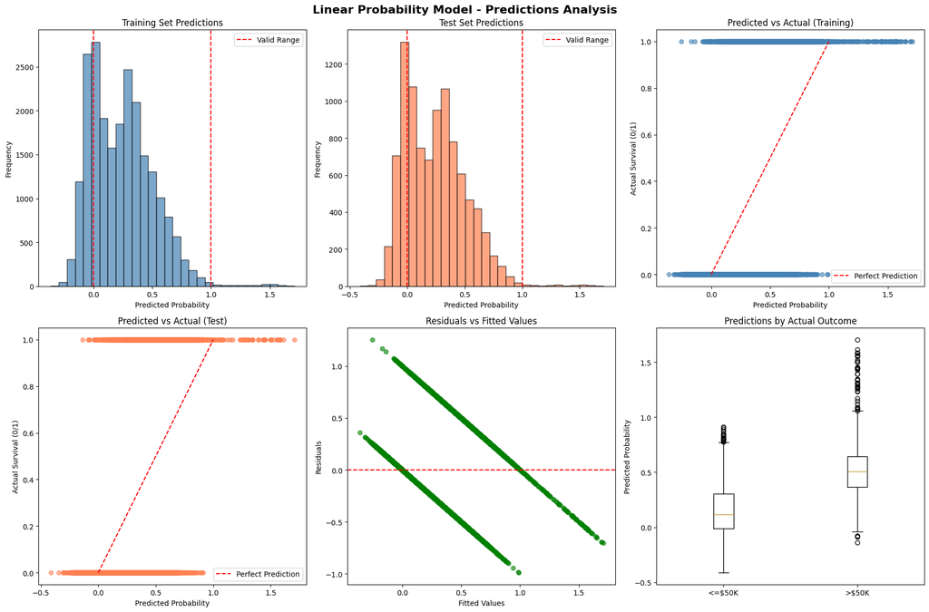

```
MOST EXTREME PREDICTIONS:
Lowest prediction: -0.4127
Highest prediction: 1.7062
```

```python
# Generate predictions for both training and test sets
y_pred_lpm_traint = lpm_results.predict(X_train_constt)
y_pred_lpm_testt = lpm_results.predict(X_test_constt)

print("PREDICTION ANALYSIS - LINEAR PROBABILITY MODEL:")
print("-" * 50)

# Check for impossible predictions (outside [0,1])
train_impossible = ((y_pred_lpm_traint < 0) | (y_pred_lpm_traint > 1)).sum()
test_impossible = ((y_pred_lpm_testt < 0) | (y_pred_lpm_testt > 1)).sum()

print(f"IMPOSSIBLE PREDICTIONS ANALYSIS:")
print(f"Training set: {train_impossible}/{len(y_pred_lpm_traint)} ({train_impossible/len(y_pred_lpm_traint)*100:.1f}%) outside [0,1]")
print(f"Test set: {test_impossible}/{len(y_pred_lpm_testt)} ({test_impossible/len(y_pred_lpm_testt)*100:.1f}%) outside [0,1]")

print(f"\nPREDICTION STATISTICS:")
print("-" * 25)
print(f"Training predictions - Min: {y_pred_lpm_traint.min():.4f}, Max: {y_pred_lpm_traint.max():.4f}")
print(f"Test predictions - Min: {y_pred_lpm_testt.min():.4f}, Max: {y_pred_lpm_testt.max():.4f}")

# Create visualization
fig, axes = plt.subplots(2, 3, figsize=(18, 12))
fig.suptitle('Linear Probability Model - Predictions Analysis', fontsize=16, fontweight='bold')

# 1. Histogram of training predictions
ax1 = axes[0, 0]
ax1.hist(y_pred_lpm_train, bins=30, alpha=0.7, color='steelblue', edgecolor='black')
ax1.axvline(0, color='red', linestyle='--', label='Valid Range')
ax1.axvline(1, color='red', linestyle='--')
ax1.set_title('Training Set Predictions')
ax1.set_xlabel('Predicted Probability')
ax1.set_ylabel('Frequency')
ax1.legend()

# 2. Histogram of test predictions
ax2 = axes[0, 1]
ax2.hist(y_pred_lpm_testt, bins=30, alpha=0.7, color='coral', edgecolor='black')
ax2.axvline(0, color='red', linestyle='--', label='Valid Range')
ax2.axvline(1, color='red', linestyle='--')
ax2.set_title('Test Set Predictions')
ax2.set_xlabel('Predicted Probability')
ax2.set_ylabel('Frequency')
ax2.legend()

# 3. Predicted vs Actual - Training
ax3 = axes[0, 2]
ax3.scatter(y_pred_lpm_traint, y_traint, alpha=0.6, color='steelblue')
ax3.plot([0, 1], [0, 1], 'r--', label='Perfect Prediction')
ax3.set_title('Predicted vs Actual (Training)')
ax3.set_xlabel('Predicted Probability')
ax3.set_ylabel('Actual Survival (0/1)')
ax3.legend()

# 4. Predicted vs Actual - Test
ax4 = axes[1, 0]
ax4.scatter(y_pred_lpm_testt, y_test, alpha=0.6, color='coral')
ax4.plot([0, 1], [0, 1], 'r--', label='Perfect Prediction')
ax4.set_title('Predicted vs Actual (Test)')
ax4.set_xlabel('Predicted Probability')
ax4.set_ylabel('Actual Survival (0/1)')
ax4.legend()

# 5. Residuals vs Fitted
ax5 = axes[1, 1]
residuals_train = y_traint - y_pred_lpm_train
ax5.scatter(y_pred_lpm_traint, residuals_train, alpha=0.6, color='green')
ax5.axhline(0, color='red', linestyle='--')
ax5.set_title('Residuals vs Fitted Values')
ax5.set_xlabel('Fitted Values')
ax5.set_ylabel('Residuals')

# 6. Box plot by actual survival
ax6 = axes[1, 2]
survival_groups = [y_pred_lpm_testt[y_test == 0], y_pred_lpm_testt[y_test == 1]]
ax6.boxplot(survival_groups, labels=['<=$50K', '>$50K'])
ax6.set_title('Predictions by Actual Outcome')
ax6.set_ylabel('Predicted Probability')

plt.tight_layout()
plt.show()

# Identify most problematic predictions
if train_impossible > 0 or test_impossible > 0:
    print(f"\nMOST EXTREME PREDICTIONS:")
    all_predictions = np.concatenate([y_pred_lpm_traint, y_pred_lpm_testt])
    print(f"Lowest prediction: {all_predictions.min():.4f}")
    print(f"Highest prediction: {all_predictions.max():.4f}")
```

```
LINEAR PROBABILITY MODEL - CLASSIFICATION PERFORMANCE:
-------------------------------------------------------
Using threshold: 0.5

========================================
CONFUSION MATRIX ANALYSIS
========================================
TRAINING SET CONFUSION MATRIX:
-----------------------------------
                 Predicted
              <=$50K    <=$50K
Actual <=$50K   16363      940
       <=$50K  2679     2810

TEST SET CONFUSION MATRIX:
------------------------------
                 Predicted
              <=$50K    <=$50K
Actual <=$50K   7006      411
       <=$50K  1150     1202

========================================
KEY PERFORMANCE METRICS
========================================
        Metric                                Formula  Training    Test  \
0     Accuracy                      (TP + TN) / Total    0.8412  0.8402
1    Precision                         TP / (TP + FP)    0.7493  0.7452
2       Recall                         TP / (TP + FN)    0.5119  0.5111
3  Specificity                         TN / (TN + FP)    0.9457  0.9446
4     F1-Score  2 × (Prec × Recall) / (Prec + Recall)    0.6083  0.6063

                        Interpretation
0          Overall correct predictions
1  Reliability of survival predictions
2    Ability to catch actual survivors
3           Ability to identify deaths
4      Balance of precision and recall

DETAILED INTERPRETATION:
-------------------------
1. ACCURACY (0.840):
   → 84.0% of all predictions are correct

2. PRECISION (0.745):
   → Of passengers predicted to survive, 74.5% actually did

3. RECALL (0.511):
   → Of passengers who actually survived, we identified 51.1%

4. SPECIFICITY (0.945):
   → Of passengers who actually died, we correctly identified 94.5%

5. F1-SCORE (0.606):
   → Balanced measure combining precision and recall
```

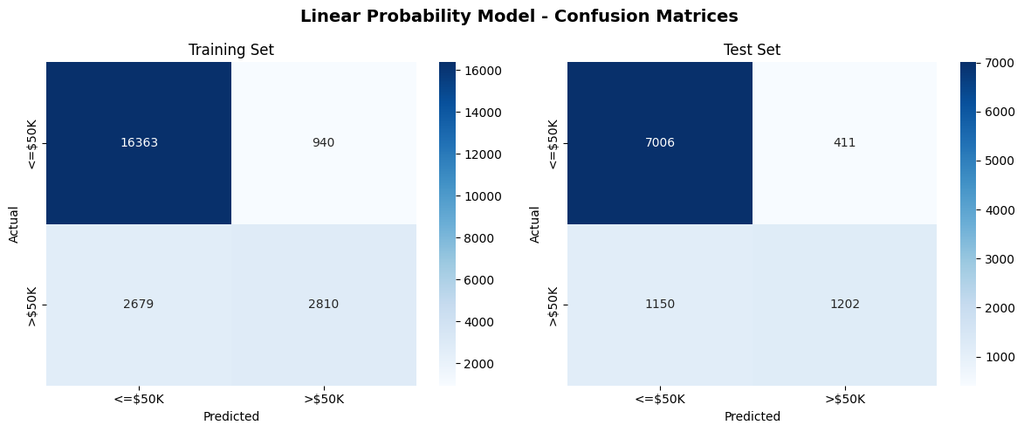

```python
print("LINEAR PROBABILITY MODEL - CLASSIFICATION PERFORMANCE:")
print("-" * 55)

# Convert probabilities to binary predictions using 0.5 threshold
threshold = 0.5
y_pred_binary_traint = (y_pred_lpm_traint >= threshold).astype(int)
y_pred_binary_testt = (y_pred_lpm_testt >= threshold).astype(int)

print(f"Using threshold: {threshold}")

# Confusion Matrix Analysis
print("\n" + "="*40)
print("CONFUSION MATRIX ANALYSIS")
print("="*40)

# Training set confusion matrix
cm_train = confusion_matrix(y_traint, y_pred_binary_traint)
tn_train, fp_train, fn_train, tp_train = cm_train.ravel()

print(f"TRAINING SET CONFUSION MATRIX:")
print("-" * 35)
print("                 Predicted")
print("              <=$50K    <=$50K")
print(f"Actual <=$50K   {tn_train:4d}     {fp_train:4d}")
print(f"       <=$50K  {fn_train:4d}     {tp_train:4d}")

# Test set confusion matrix
cm_test = confusion_matrix(y_test, y_pred_binary_testt)
tn_test, fp_test, fn_test, tp_test = cm_test.ravel()

print(f"\nTEST SET CONFUSION MATRIX:")
print("-" * 30)
print("                 Predicted")
print("              <=$50K    <=$50K")
print(f"Actual <=$50K   {tn_test:4d}     {fp_test:4d}")
print(f"       <=$50K  {fn_test:4d}     {tp_test:4d}")

# Calculate all metrics
def calculate_metrics(y_true, y_pred):
    accuracy = accuracy_score(y_true, y_pred)
    precision = precision_score(y_true, y_pred)
    recall = recall_score(y_true, y_pred)
    f1 = f1_score(y_true, y_pred)

    # Calculate specificity manually
    cm = confusion_matrix(y_true, y_pred)
    tn, fp, fn, tp = cm.ravel()
    specificity = tn / (tn + fp) if (tn + fp) > 0 else 0

    return {
        'accuracy': accuracy,
        'precision': precision,
        'recall': recall,
        'specificity': specificity,
        'f1': f1
    }

train_metrics = calculate_metrics(y_traint, y_pred_binary_traint)
test_metrics = calculate_metrics(y_test, y_pred_binary_testt)

# Create metrics comparison table
print("\n" + "="*40)
print("KEY PERFORMANCE METRICS")
print("="*40)

metrics_df = pd.DataFrame({
    'Metric': ['Accuracy', 'Precision', 'Recall', 'Specificity', 'F1-Score'],
    'Formula': [
        '(TP + TN) / Total',
        'TP / (TP + FP)',
        'TP / (TP + FN)',
        'TN / (TN + FP)',
        '2 × (Prec × Recall) / (Prec + Recall)'
    ],
    'Training': [
        train_metrics['accuracy'],
        train_metrics['precision'],
        train_metrics['recall'],
        train_metrics['specificity'],
        train_metrics['f1']
    ],
    'Test': [
        test_metrics['accuracy'],
        test_metrics['precision'],
        test_metrics['recall'],
        test_metrics['specificity'],
        test_metrics['f1']
    ],
    'Interpretation': [
        'Overall correct predictions',
        'Reliability of survival predictions',
        'Ability to catch actual survivors',
        'Ability to identify deaths',
        'Balance of precision and recall'
    ]
})

print(metrics_df.round(4))

print(f"\nDETAILED INTERPRETATION:")
print("-" * 25)
print(f"1. ACCURACY ({test_metrics['accuracy']:.3f}):")
print(f"   → {test_metrics['accuracy']:.1%} of all predictions are correct")

print(f"\n2. PRECISION ({test_metrics['precision']:.3f}):")
print(f"   → Of passengers predicted to survive, {test_metrics['precision']:.1%} actually did")

print(f"\n3. RECALL ({test_metrics['recall']:.3f}):")
print(f"   → Of passengers who actually survived, we identified {test_metrics['recall']:.1%}")

print(f"\n4. SPECIFICITY ({test_metrics['specificity']:.3f}):")
print(f"   → Of passengers who actually died, we correctly identified {test_metrics['specificity']:.1%}")

print(f"\n5. F1-SCORE ({test_metrics['f1']:.3f}):")
print(f"   → Balanced measure combining precision and recall")

# Visualization of confusion matrices
fig, axes = plt.subplots(1, 2, figsize=(12, 5))
fig.suptitle('Linear Probability Model - Confusion Matrices', fontsize=14, fontweight='bold')

# Training confusion matrix
sns.heatmap(cm_train, annot=True, fmt='d', cmap='Blues', ax=axes[0],
            xticklabels=['<=$50K', '>$50K'], yticklabels=['<=$50K', '>$50K'])
axes[0].set_title('Training Set')
axes[0].set_xlabel('Predicted')
axes[0].set_ylabel('Actual')

# Test confusion matrix
sns.heatmap(cm_test, annot=True, fmt='d', cmap='Blues', ax=axes[1],
            xticklabels=['<=$50K', '>$50K'], yticklabels=['<=$50K', '>$50K'])
axes[1].set_title('Test Set')
axes[1].set_xlabel('Predicted')
axes[1].set_ylabel('Actual')

plt.tight_layout()
plt.show()
```

```
PREDICTION ANALYSIS - LOGISTIC REGRESSION:
---------------------------------------------
PREDICTION RANGE VERIFICATION:
Training predictions - Min: 0.000000, Max: 1.000000
Test predictions - Min: 0.000000, Max: 1.000000
All predictions in [0,1]: ✓ YES
```

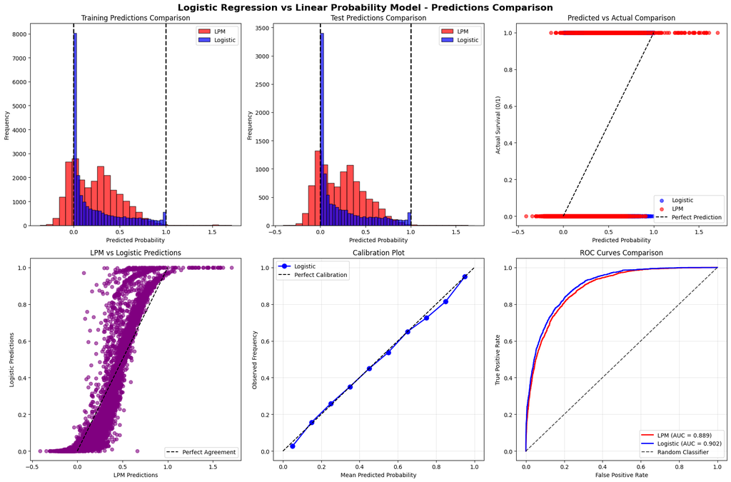

```
PREDICTION COMPARISON STATISTICS:
-----------------------------------
Correlation between LPM and Logistic predictions: 0.9065
Mean absolute difference: 0.0899
Maximum absolute difference: 0.8987
```

```python
# Generate predictions from logistic model
y_pred_logit_traint = logit_results.predict(X_train_const)
y_pred_logit_testt = logit_results.predict(X_test_const)

print("PREDICTION ANALYSIS - LOGISTIC REGRESSION:")
print("-" * 45)

# Verify all predictions are in valid range
print(f"PREDICTION RANGE VERIFICATION:")
print(f"Training predictions - Min: {y_pred_logit_traint.min():.6f}, Max: {y_pred_logit_traint.max():.6f}")
print(f"Test predictions - Min: {y_pred_logit_testt.min():.6f}, Max: {y_pred_logit_testt.max():.6f}")
print(f"All predictions in [0,1]: {'✓ YES' if (y_pred_logit_traint.min() >= 0 and y_pred_logit_traint.max() <= 1 and y_pred_logit_testt.min() >= 0 and y_pred_logit_test.max() <= 1) else '✗ NO'}")

# Create comparison visualization
fig, axes = plt.subplots(2, 3, figsize=(18, 12))
fig.suptitle('Logistic Regression vs Linear Probability Model - Predictions Comparison',
             fontsize=16, fontweight='bold')

# 1. Histogram comparison - Training
ax1 = axes[0, 0]
ax1.hist(y_pred_lpm_traint, bins=30, alpha=0.7, label='LPM', color='red', edgecolor='black')
ax1.hist(y_pred_logit_traint, bins=30, alpha=0.7, label='Logistic', color='blue', edgecolor='black')
ax1.axvline(0, color='black', linestyle='--', linewidth=2)
ax1.axvline(1, color='black', linestyle='--', linewidth=2)
ax1.set_title('Training Predictions Comparison')
ax1.set_xlabel('Predicted Probability')
ax1.set_ylabel('Frequency')
ax1.legend()

# 2. Histogram comparison - Test
ax2 = axes[0, 1]
ax2.hist(y_pred_lpm_testt, bins=30, alpha=0.7, label='LPM', color='red', edgecolor='black')
ax2.hist(y_pred_logit_testt, bins=30, alpha=0.7, label='Logistic', color='blue', edgecolor='black')
ax2.axvline(0, color='black', linestyle='--', linewidth=2)
ax2.axvline(1, color='black', linestyle='--', linewidth=2)
ax2.set_title('Test Predictions Comparison')
ax2.set_xlabel('Predicted Probability')
ax2.set_ylabel('Frequency')
ax2.legend()

# 3. Predicted vs Actual - Logistic
ax3 = axes[0, 2]
ax3.scatter(y_pred_logit_testt, y_test, alpha=0.6, color='blue', label='Logistic')
ax3.scatter(y_pred_lpm_testt, y_test, alpha=0.6, color='red', label='LPM')
ax3.plot([0, 1], [0, 1], 'k--', label='Perfect Prediction')
ax3.set_title('Predicted vs Actual Comparison')
ax3.set_xlabel('Predicted Probability')
ax3.set_ylabel('Actual Survival (0/1)')
ax3.legend()

# 4. Direct comparison of predictions
ax4 = axes[1, 0]
ax4.scatter(y_pred_lpm_testt, y_pred_logit_testt, alpha=0.6, color='purple')
ax4.plot([0, 1], [0, 1], 'k--', label='Perfect Agreement')
ax4.set_title('LPM vs Logistic Predictions')
ax4.set_xlabel('LPM Predictions')
ax4.set_ylabel('Logistic Predictions')
ax4.legend()

# 5. Calibration plot
ax5 = axes[1, 1]
# Create bins and calculate observed frequencies
n_bins = 10
bin_boundaries = np.linspace(0, 1, n_bins + 1)

# For logistic regression
logit_bin_centers = []
logit_observed = []
for i in range(n_bins):
    mask = (y_pred_logit_testt >= bin_boundaries[i]) & (y_pred_logit_testt < bin_boundaries[i+1])
    if mask.sum() > 0:
        logit_bin_centers.append((bin_boundaries[i] + bin_boundaries[i+1]) / 2)
        logit_observed.append(y_test[mask].mean())

ax5.plot(logit_bin_centers, logit_observed, 'bo-', label='Logistic', linewidth=2, markersize=8)
ax5.plot([0, 1], [0, 1], 'k--', label='Perfect Calibration')
ax5.set_title('Calibration Plot')
ax5.set_xlabel('Mean Predicted Probability')
ax5.set_ylabel('Observed Frequency')
ax5.legend()
ax5.grid(True, alpha=0.3)

# 6. ROC Curves comparison
ax6 = axes[1, 2]
# Calculate ROC for both models
fpr_lpm, tpr_lpm, _ = roc_curve(y_test, y_pred_lpm_testt)  # Fixed: was fpr_lmp, should be fpr_lpm
fpr_logit, tpr_logit, _ = roc_curve(y_test, y_pred_logit_testt)
auc_lpm = roc_auc_score(y_test, y_pred_lpm_testt)
auc_logit = roc_auc_score(y_test, y_pred_logit_testt)

ax6.plot(fpr_lpm, tpr_lpm, 'r-', linewidth=2, label=f'LPM (AUC = {auc_lpm:.3f})')  # Now works correctly
ax6.plot(fpr_logit, tpr_logit, 'b-', linewidth=2, label=f'Logistic (AUC = {auc_logit:.3f})')
ax6.plot([0, 1], [0, 1], 'k--', alpha=0.7, label='Random Classifier')
ax6.set_title('ROC Curves Comparison')
ax6.set_xlabel('False Positive Rate')
ax6.set_ylabel('True Positive Rate')
ax6.legend()
ax6.grid(True, alpha=0.3)

plt.tight_layout()
plt.show()

# Print comparison statistics
print(f"\nPREDICTION COMPARISON STATISTICS:")
print("-" * 35)
print(f"Correlation between LPM and Logistic predictions: {np.corrcoef(y_pred_lpm_testt, y_pred_logit_testt)[0,1]:.4f}")
print(f"Mean absolute difference: {np.mean(np.abs(y_pred_lpm_testt - y_pred_logit_testt)):.4f}")
print(f"Maximum absolute difference: {np.max(np.abs(y_pred_lpm_testt - y_pred_logit_testt)):.4f}")
```

```
LOGISTIC REGRESSION - CLASSIFICATION PERFORMANCE:
--------------------------------------------------
CONFUSION MATRICES:
--------------------
```

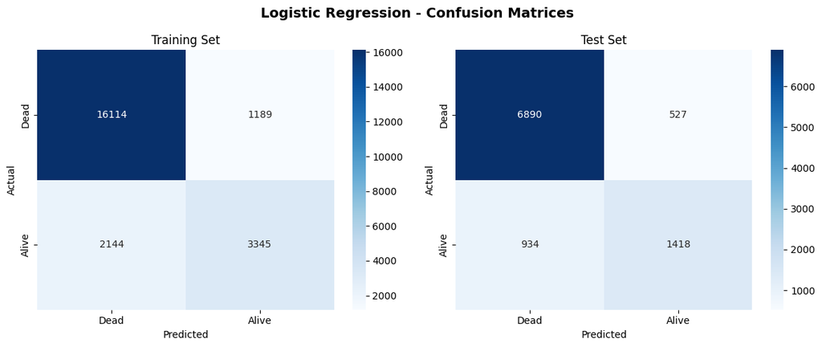

```
CLASSIFICATION METRICS COMPARISON:
----------------------------------------
        Metric  LPM_Train  LPM_Test  Logistic_Train  Logistic_Test
0     Accuracy     0.8412    0.8402          0.8538         0.8504
1    Precision     0.7493    0.7452          0.7378         0.7290
2       Recall     0.5119    0.5111          0.6094         0.6029
3  Specificity     0.9457    0.9446          0.9313         0.9289
4     F1-Score     0.6083    0.6063          0.6675         0.6600

ROC ANALYSIS:
---------------
LPM AUC: 0.8888
Logistic AUC: 0.9021
AUC Improvement: 0.0132
```

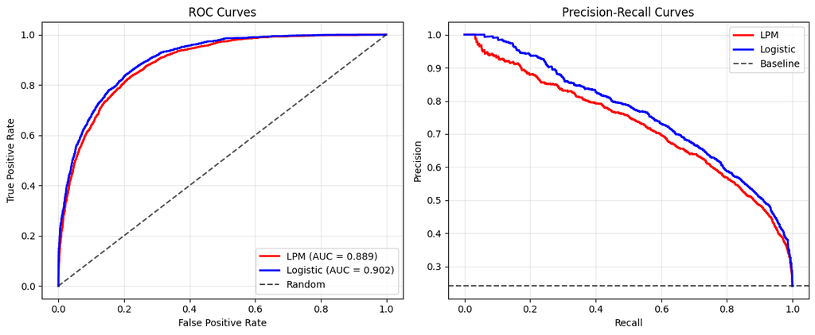

```python
print("LOGISTIC REGRESSION - CLASSIFICATION PERFORMANCE:")
print("-" * 50)

# Convert probabilities to binary predictions
y_pred_logit_binary_traint = (y_pred_logit_traint >= 0.5).astype(int)
y_pred_logit_binary_testt = (y_pred_logit_testt >= 0.5).astype(int)

# Calculate confusion matrices
cm_logit_traint = confusion_matrix(y_traint, y_pred_logit_binary_traint)
cm_logit_testt = confusion_matrix(y_test, y_pred_logit_binary_testt)

print("CONFUSION MATRICES:")
print("-" * 20)

# Display confusion matrices
fig, axes = plt.subplots(1, 2, figsize=(12, 5))
fig.suptitle('Logistic Regression - Confusion Matrices', fontsize=14, fontweight='bold')

sns.heatmap(cm_logit_traint, annot=True, fmt='d', cmap='Blues', ax=axes[0],
            xticklabels=['Dead', 'Alive'], yticklabels=['Dead', 'Alive'])
axes[0].set_title('Training Set')
axes[0].set_xlabel('Predicted')
axes[0].set_ylabel('Actual')

sns.heatmap(cm_logit_testt, annot=True, fmt='d', cmap='Blues', ax=axes[1],
            xticklabels=['Dead', 'Alive'], yticklabels=['Dead', 'Alive'])
axes[1].set_title('Test Set')
axes[1].set_xlabel('Predicted')
axes[1].set_ylabel('Actual')

plt.tight_layout()
plt.show()

# Calculate comprehensive metrics
logit_train_metrics = calculate_metrics(y_traint, y_pred_logit_binary_traint)
logit_test_metrics = calculate_metrics(y_test, y_pred_logit_binary_testt)

print("\nCLASSIFICATION METRICS COMPARISON:")
print("-" * 40)

# Create comprehensive comparison
comparison_df = pd.DataFrame({
    'Metric': ['Accuracy', 'Precision', 'Recall', 'Specificity', 'F1-Score'],
    'LPM_Train': [train_metrics['accuracy'], train_metrics['precision'],
                 train_metrics['recall'], train_metrics['specificity'], train_metrics['f1']],
    'LPM_Test': [test_metrics['accuracy'], test_metrics['precision'],
                test_metrics['recall'], test_metrics['specificity'], test_metrics['f1']],
    'Logistic_Train': [logit_train_metrics['accuracy'], logit_train_metrics['precision'],
                      logit_train_metrics['recall'], logit_train_metrics['specificity'],
                      logit_train_metrics['f1']],
    'Logistic_Test': [logit_test_metrics['accuracy'], logit_test_metrics['precision'],
                     logit_test_metrics['recall'], logit_test_metrics['specificity'],
                     logit_test_metrics['f1']]
})

print(comparison_df.round(4))

# ROC Analysis
print(f"\nROC ANALYSIS:")
print("-" * 15)
print(f"LPM AUC: {auc_lpm:.4f}")
print(f"Logistic AUC: {auc_logit:.4f}")
print(f"AUC Improvement: {auc_logit - auc_lpm:.4f}")

# Create comprehensive ROC and PR curves
fig, axes = plt.subplots(1, 2, figsize=(12, 5))

# ROC Curves
fpr_lmp, tpr_lpm, thresholds_lpm = roc_curve(y_test, y_pred_lpm_testt)
fpr_logit, tpr_logit, thresholds_logit = roc_curve(y_test, y_pred_logit_testt)

axes[0].plot(fpr_lpm, tpr_lpm, 'r-', linewidth=2, label=f'LPM (AUC = {auc_lpm:.3f})')
axes[0].plot(fpr_logit, tpr_logit, 'b-', linewidth=2, label=f'Logistic (AUC = {auc_logit:.3f})')
axes[0].plot([0, 1], [0, 1], 'k--', alpha=0.7, label='Random')
axes[0].set_xlabel('False Positive Rate')
axes[0].set_ylabel('True Positive Rate')
axes[0].set_title('ROC Curves')
axes[0].legend()
axes[0].grid(True, alpha=0.3)

# Precision-Recall Curves
precision_lpm, recall_lpm, _ = precision_recall_curve(y_test, y_pred_lpm_testt)
precision_logit, recall_logit, _ = precision_recall_curve(y_test, y_pred_logit_testt)

axes[1].plot(recall_lpm, precision_lpm, 'r-', linewidth=2, label='LPM')
axes[1].plot(recall_logit, precision_logit, 'b-', linewidth=2, label='Logistic')
axes[1].axhline(y=y_test.mean(), color='k', linestyle='--', alpha=0.7, label='Baseline')
axes[1].set_xlabel('Recall')
axes[1].set_ylabel('Precision')
axes[1].set_title('Precision-Recall Curves')
axes[1].legend()
axes[1].grid(True, alpha=0.3)

plt.tight_layout()
plt.show()
```

## Interpretation are from the old model and not the tuned one but since values are the same, it's the same

## Coefficient Interpretation

*Top 1 - 5 highest coefficient score*

1. Assuming all the other variables are constant, being Female has a 97.7% decrease in the odds of having a high income(>$50K)

This makes sense for me as this dataset was from the 90s meaning sexism was still normal and not frowned upon unlike today.

2. Assuming all the other variables are constant, each additional hour worked per week is associated to a 3% increase in the odds of having a high income (>$50K)

This makes sense to me as well as more hours on working should equal getting paid more specially if you're getting paid by the hour.

3. Assuming all the other variables are constant, each additional year of age is associated with a 2.5% increase in likelihood of having high income(>$50K)

This makes sense to me as well since experience is key to getting jobs and getting promoted although a fatal flaw is having too much age i.e. 70 years old or more.

4. Assuming all other variables are constant, each unit increase in capital loss is associated with a 0.06% higher likelihood of having high income

This one is confusing for me since losing value for the whole city should equate in lower payment too but it is reverse, getting more and more capital loss equates to higher chance to have more than $50K in salary.

5. Assuming all other variables are constant each unit of increase in capital gain is associated with a 0.03% increase in the odds of having high income (>50K)

This makes more sense to me than number 4 as if your capital gains more, everything should increase with it.

## Choosing which columns to remove

Im considering removing relationships, it describes what the role of the person is inside the household which could be easily identified with marital status for example: if married and male then husband or if single and female then daughter. It makes sense for me to remove this column. Im also considering removing the education-num column as it just provides the same information as the education columns the only difference being the education-num being numerical and continuous and the education column being categorical, the education column is definitely better for this and the education num is just extra. The other columns seem fine to keep for me so I would just limit the removal of columns to just the relationship column and education-num column as I dont want to remove any column that I dont deem as necessary to remove.